# Snake_venom_analysis

Kevin Healy

15 Jan 2018

# Upload stuff

## Packages

First the required packages are uplaoded. These include .MCMCglmm’ which is used for the main linear analysis, ‘phytools’ and ‘caper’. to handle the phylogenies and finaly ‘hdrcde’, ‘wesanderson’ and the ‘MultiDisPlot.R’ function to make some of the plots.

```r
library(phytools)
library(caper)
library(MCMCglmm)
library(wesanderson)
library(hdrcde)
```

```r
source("MultiDisPlot.R")
```

## data

Next we uplaod the main data file. See the methods section in the main paper for a description of the data.

```r
ld50_data <- read.csv("S2_snake_data.csv",header=T,sep=",")
```

## Phylogeny

We use the phylogeny from Pyron et al 2014 to control for phylogeny in our main model.

```r
tree <- read.tree("liz_and_snake_time_tree.txt")
#this seems to fix a dublicate problem caused by polynomies in the tree
Tree<-makeLabel(tree)
Tree<-makeLabel(Tree)
```

## Data transformation

```r
ld50_clean  <- ld50_data
#length
len.v <- log10(ld50_clean$length_cm)
len.v <- (len.v - mean(len.v))/(sd(len.v))

#mass
mass <- log10(ld50_clean $mass_grams)
mass <- (mass- mean(mass))/(sd(mass))

animal <- ld50_clean $species
species <- ld50_clean $species

##volume
vol.v <- log10(as.numeric(as.vector(ld50_clean $venom_yield_mg)))
vol.v <- (vol.v - mean(vol.v))/(sd(vol.v))

#dimension
dimensions <- ld50_clean $dimensions

#LD50
ld50_10 <- log10(as.vector(ld50_clean $ld50_mg))
ld50_mg <- (ld50_10- mean(ld50_10))/(sd(ld50_10))


ld50_method <- ld50_clean $ld50_method

eggs <- ld50_clean[,c("eggs")]
egg.bin <- rep(0,length(eggs))
for(i in 1:(length(eggs))){

if(ld50_clean[i,c("eggs")] > 0) egg.bin[i] <- "yes"
else egg.bin[i] <- "no"
}

weigted.dist.v <- (ld50_clean$phylo_distance_diet_model_my)
weigted.dist.v <- (weigted.dist.v- mean(weigted.dist.v))/(sd(weigted.dist.v))

env <- ld50_clean$environment

con <- ld50_clean$constriction

fam <- ld50_clean$family


mod_class <- ld50_clean$ld50_model_class
```

## full model

Now we set up the model to insure that there is a corresponding animal column within the dataframe in order for the phylogeny to match up. We also include as speerate “species” term to account for variation assocaited with multiple measures for a single species.

```r
###full model variables
mydat.max <- data.frame(animal,
                        species,
                        mass,
                        weigted.dist.v = weigted.dist.v,
                        vol.v,
                        dimensions = dimensions,
                        ld50 = ld50_10,
                        ld50_method,
                        dimensions,
                        egg.bin,
                        env,
                        con,
                        fam)

spec_dropped <-as.data.frame(matrix(0, nrow = c(length(levels(mydat.max[,"species"]))),
                                    ncol = c(2), dimnames = list(c(),c("species","dummy"))))
spec_dropped[,1] <- levels(mydat.max$species)
spec_dropped[,2] <- rep(0,length = c(length(levels(mydat.max[,"species"]))))
spec_dropped <- as.data.frame(spec_dropped)

max.dat <- comparative.data(data= spec_dropped,
                            phy= Tree,
                            names.col="species",
                            vcv=FALSE)

max.tree <- chronoMPL(max.dat$phy)

max.dropped <- max.dat$dropped$unmatched.rows

mydat.MAX <- mydat.max
if((length(max.dropped) > c(0)) == TRUE){
for(i in 1:(length(max.dropped))){
mydat.MAX <-mydat.MAX[mydat.MAX$species != max.dropped[i],]
}
}


##clean up the final matched data.frame
mydat.MAX <- as.data.frame(as.matrix(mydat.MAX))

mydat.MAX <- data.frame(animal = mydat.MAX$species,
species = mydat.MAX$species,
mass.aa = (as.numeric(as.character(mydat.MAX$mass))),
weigted.dist.v = (as.numeric(as.character(mydat.MAX$weigted.dist.v))),
vol.v = (as.numeric(as.character(mydat.MAX$vol.v))),
ld50 = (as.numeric(as.character(mydat.MAX$ld50))),
ld50_method  = factor(mydat.MAX$ld50_method,
                       levels = c("sc","iv","ip","im")),
dim = mydat.MAX$dimensions,
egg.bin = mydat.MAX$egg.bin,
env = factor(mydat.MAX$env,
             levels = c("terrestrial","arboreal","aquatic")),
con = mydat.MAX$con,
fam = mydat.MAX$fam)
```

## Set the parameters

Here we set the number of iterations, the thinning and the burn-in

```r
#if you want to include species and ld50 method as a fixed term.

#nitt <- 1200000
#thin <- 500
#burnin <- 200000

nitt <- 12000
thin <- 5
burnin <- 2000
```

## Set the prior

```r
prior<-list(R = list(V = diag(2), nu=0.002),
            G = list(G1=list(V = diag(2)/2,n = 2,
                             alpha.mu=rep(0,2),
                             alpha.V=diag(2)*10^3),
                     G2=list(V = diag(2)/2,n = 2,
                             alpha.mu=rep(0,2),
                             alpha.V=diag(2)*10^3)))
```

## Run the full model

Now we run the full model with both venom volume and Ld50 included as response variables. We also allow for co-variance between these two terms.

```r
full_model <- MCMCglmm(cbind(vol.v,ld50) ~
                         trait:mass.aa +
                         trait:ld50_method +
                         trait:dim +
                         trait:egg.bin +
                         trait:weigted.dist.v,
                       random = ~us(trait):animal +
                                 us(trait):species,
                       rcov=~us(trait):units,
                       data = mydat.MAX,
                       pedigree = max.tree,
                       prior = prior,
                       family=c("gaussian","gaussian"),
                       nitt = nitt, thin = thin, burnin = burnin,
                       verbose= FALSE)

summary(full_model)
```

```
##
##  Iterations = 2001:11996
##  Thinning interval  = 5
##  Sample size  = 2000
##
##  DIC: -59.19101
##
##  G-structure:  ~us(trait):animal
##
##                              post.mean l-95% CI u-95% CI eff.samp
## traitvol.v:traitvol.v.animal    0.3550  0.07212   0.6819    109.9
## traitld50:traitvol.v.animal    -0.0290 -0.20515   0.1777    296.6
## traitvol.v:traitld50.animal    -0.0290 -0.20515   0.1777    296.6
## traitld50:traitld50.animal      0.4037  0.14745   0.6724    336.6
##
##                ~us(trait):species
##
##                               post.mean   l-95% CI u-95% CI eff.samp
## traitvol.v:traitvol.v.species   0.27812  1.581e-01  0.40233    325.2
## traitld50:traitvol.v.species    0.02570 -3.578e-02  0.09297    349.1
## traitvol.v:traitld50.species    0.02570 -3.578e-02  0.09297    349.1
## traitld50:traitld50.species     0.03699  2.264e-09  0.10147    271.4
##
##  R-structure:  ~us(trait):units
##
##                             post.mean  l-95% CI u-95% CI eff.samp
## traitvol.v:traitvol.v.units 0.0088096  0.007531 0.010277     2000
## traitld50:traitvol.v.units  0.0008607 -0.004330 0.005394     2000
## traitvol.v:traitld50.units  0.0008607 -0.004330 0.005394     2000
## traitld50:traitld50.units   0.2289394  0.193973 0.265504     2296
##
##  Location effects: cbind(vol.v, ld50) ~ trait:mass.aa + trait:ld50_method + trait:dim + trait:egg.bin + trait:weigted.dist.v
##
##                           post.mean  l-95% CI  u-95% CI eff.samp  pMCMC
## (Intercept)                0.216012 -0.142261  0.571578     1361  0.221
## traitvol.v:mass.aa         0.481051  0.425981  0.535202     1866 <5e-04
## traitld50:mass.aa          0.080958 -0.017260  0.169823     1453  0.101
## traitvol.v:ld50_methodiv  -0.001182 -0.033945  0.029755     2275  0.937
## traitld50:ld50_methodiv   -0.452712 -0.595186 -0.287783     1849 <5e-04
## traitvol.v:ld50_methodip  -0.013430 -0.047066  0.019191     1770  0.434
```

[output cut: 12 more lines]

```
## traitld50:mass.aa
## traitvol.v:ld50_methodiv
## traitld50:ld50_methodiv   ***
## traitvol.v:ld50_methodip
## traitld50:ld50_methodip   ***
## traitvol.v:ld50_methodim
## traitld50:ld50_methodim   .
## traitvol.v:dim3           ***
## traitld50:dim3
## traitvol.v:egg.binyes     .
## traitld50:egg.binyes      ***
## traitvol.v:weigted.dist.v
## traitld50:weigted.dist.v  ***
## ---
## Signif. codes:  0 '***' 0.001 '**' 0.01 '*' 0.05 '.' 0.1 ' ' 1
```

## Run the full model

Now we calulated the proportion of variance associated with phylogeny, species level and risidual for both volume and LD50

```r
ld_50_prop_phlyo <- full_model$VCV[,"traitld50:traitld50.animal"]/
                    (full_model$VCV[,"traitld50:traitld50.animal"] +
                     full_model$VCV[,"traitld50:traitld50.species"] +
                     full_model$VCV[,"traitld50:traitld50.units"] +
                         full_model$VCV[,"traitld50:traitvol.v.animal"] +
                         full_model$VCV[,"traitld50:traitvol.v.species"] +
                         full_model$VCV[,"traitld50:traitvol.v.units"])

ld_50_prop_species <- full_model$VCV[,"traitld50:traitld50.species"]/
                    (full_model$VCV[,"traitld50:traitld50.animal"] +
                     full_model$VCV[,"traitld50:traitld50.species"] +
                     full_model$VCV[,"traitld50:traitld50.units"]+
                         full_model$VCV[,"traitld50:traitvol.v.animal"] +
                         full_model$VCV[,"traitld50:traitvol.v.species"] +
                         full_model$VCV[,"traitld50:traitvol.v.units"])

ld_50_prop_units <- full_model$VCV[,"traitld50:traitld50.units"]/
                    (full_model$VCV[,"traitld50:traitld50.animal"] +
                     full_model$VCV[,"traitld50:traitld50.species"] +
                     full_model$VCV[,"traitld50:traitld50.units"]+
                         full_model$VCV[,"traitld50:traitvol.v.animal"] +
                         full_model$VCV[,"traitld50:traitvol.v.species"] +
                         full_model$VCV[,"traitld50:traitvol.v.units"])

hdr(ld_50_prop_phlyo)
```

```
## $hdr
##          [,1]      [,2]
## 99% 0.1963782 0.9815113
## 95% 0.3024079 0.8736342
## 50% 0.5212930 0.7050474
##
## $mode
## [1] 0.6166405
##
## $falpha
##        1%        5%       50%
## 0.1098231 0.4481340 2.1617220
```

```r
hdr(ld_50_prop_species)
```

```
## $hdr
##             [,1]       [,2]       [,3]      [,4]       [,5]       [,6]
## 99% -0.008576961 0.20527798 0.20601921 0.2259545 0.24393383 0.25483395
## 95% -0.006883357 0.16819189 0.17980125 0.1904613         NA         NA
## 50% -0.003812125 0.04055259 0.04909567 0.0509818 0.06458703 0.06633941
##
## $mode
## [1] 0.00293022
##
## $falpha
##        1%        5%       50%
## 0.4089297 1.2531627 5.6911836
```

```r
hdr(ld_50_prop_units)
```

```
## $hdr
##          [,1]      [,2]
## 99% 0.1702329 0.5894397
## 95% 0.2004366 0.5283979
## 50% 0.2853744 0.3983320
##
## $mode
## [1] 0.3387346
##
## $falpha
##        1%        5%       50%
## 0.3098090 0.8422691 3.6522562
```

```r
vol_prop_phlyo <-  full_model$VCV[,"traitvol.v:traitvol.v.animal"]/
                    (full_model$VCV[,"traitvol.v:traitvol.v.animal"] +
                     full_model$VCV[,"traitvol.v:traitvol.v.species"] +
                     full_model$VCV[,"traitvol.v:traitvol.v.units"] +
                         full_model$VCV[,"traitld50:traitvol.v.animal"] +
                         full_model$VCV[,"traitld50:traitvol.v.species"] +
                         full_model$VCV[,"traitld50:traitvol.v.units"])

vol_prop_spec <-  full_model$VCV[,"traitld50:traitvol.v.species"]/
                    (full_model$VCV[,"traitvol.v:traitvol.v.animal"] +
                     full_model$VCV[,"traitvol.v:traitvol.v.species"] +
                     full_model$VCV[,"traitvol.v:traitvol.v.units"] +
                         full_model$VCV[,"traitld50:traitvol.v.animal"] +
                         full_model$VCV[,"traitld50:traitvol.v.species"] +
                         full_model$VCV[,"traitld50:traitvol.v.units"])

vol_prop_units <-  full_model$VCV[,"traitvol.v:traitvol.v.units"]/
                    (full_model$VCV[,"traitvol.v:traitvol.v.animal"] +
                     full_model$VCV[,"traitvol.v:traitvol.v.species"] +
                     full_model$VCV[,"traitvol.v:traitvol.v.units"] +
                         full_model$VCV[,"traitld50:traitvol.v.animal"] +
                         full_model$VCV[,"traitld50:traitvol.v.species"] +
                         full_model$VCV[,"traitld50:traitvol.v.units"])


hdr(vol_prop_phlyo)
```

```
## $hdr
##           [,1]      [,2]
## 99% 0.09121722 1.0062366
## 95% 0.18983890 0.8806039
## 50% 0.42615373 0.6667385
##
## $mode
## [1] 0.5577466
##
## $falpha
##        1%        5%       50%
## 0.1157551 0.3951523 1.7271356
```

```r
hdr(vol_prop_spec)
```

```
## $hdr
##            [,1]       [,2]
## 99% -0.09435782 0.20924165
## 95% -0.05561659 0.16206301
## 50% -0.01091078 0.05485767
##
## $mode
## [1] 0.005372038
##
## $falpha
##        1%        5%       50%
## 0.1821686 0.9118964 5.7350866
```

```r
hdr(vol_prop_units)
```

```
## $hdr
##            [,1]       [,2]
## 99% 0.006400476 0.02620125
## 95% 0.007434244 0.02224440
## 50% 0.010766979 0.01577855
##
## $mode
## [1] 0.01301505
##
## $falpha
##        1%        5%       50%
##  4.645133 13.467456 80.008164
```

### plot the full model

We plot the posterior distributions in a table using the `MultiDisPlot` function.

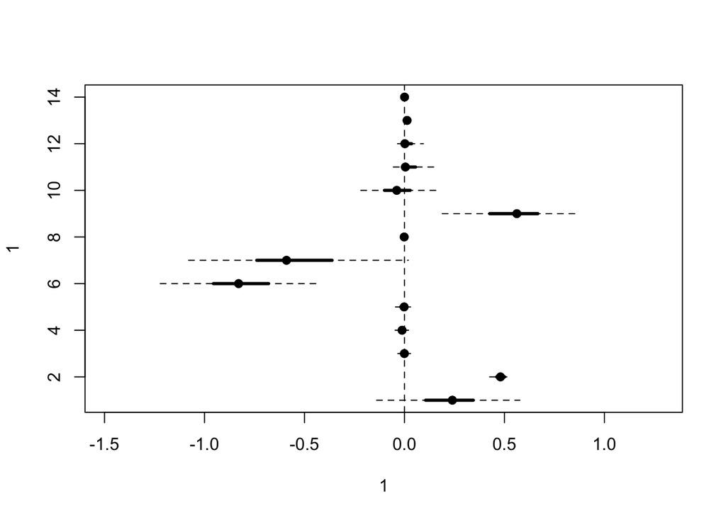

```r
vol_post <- list(full_model$Sol[,1],
                 full_model$Sol[,"traitvol.v:mass.aa"],
                 full_model$Sol[,"traitvol.v:ld50_methodiv"],
                 full_model$Sol[,"traitvol.v:ld50_methodip"],
                 full_model$Sol[,"traitvol.v:ld50_methodim"],
                 full_model$Sol[,"traitvol.v:dim3"],
                 full_model$Sol[,"traitvol.v:egg.binyes"],
                 full_model$Sol[,"traitvol.v:weigted.dist.v"],
                 vol_prop_phlyo,
                 full_model$VCV[,"traitld50:traitvol.v.animal"],
                 vol_prop_spec,
                 full_model$VCV[,"traitld50:traitvol.v.species"],
                 vol_prop_units,
                 full_model$VCV[,"traitld50:traitvol.v.units"])
MultiDisPlot(vol_post)
abline(v = 0, lty = 2)
```

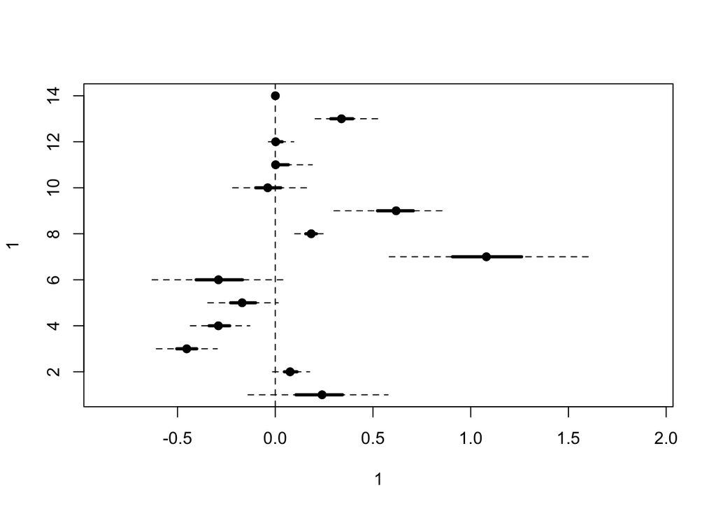

```r
ld50_post <- list(full_model$Sol[,1],
                 full_model$Sol[,"traitld50:mass.aa"],
                 full_model$Sol[,"traitld50:ld50_methodiv"],
                 full_model$Sol[,"traitld50:ld50_methodip"],
                 full_model$Sol[,"traitld50:ld50_methodim"],
                 full_model$Sol[,"traitld50:dim3"],
                 full_model$Sol[,"traitld50:egg.binyes"],
                 full_model$Sol[,"traitld50:weigted.dist.v"],
                 ld_50_prop_phlyo,
                 full_model$VCV[,"traitld50:traitvol.v.animal"],
                 ld_50_prop_species,
                 full_model$VCV[,"traitld50:traitvol.v.species"],
                 ld_50_prop_units,
                 full_model$VCV[,"traitld50:traitvol.v.units"]
                 )
MultiDisPlot(ld50_post)
abline(v = 0, lty = 2)
```

# Main figure Plots

Lets plot the main analysis First the volume plot

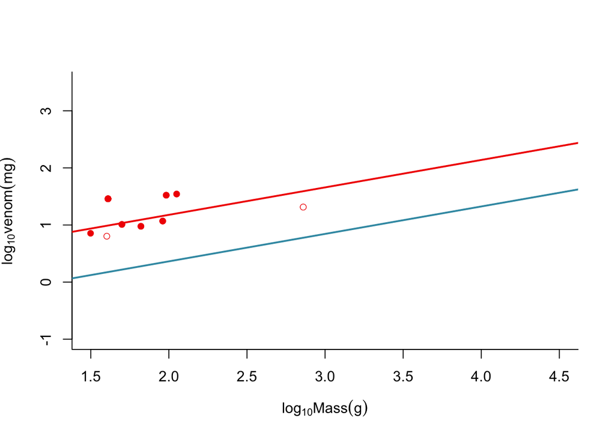

```r
pal <- wes_palette("Zissou", 4, type = "continuous")


#pdf("vol_plot.pdf")
plot(mydat.MAX[mydat.MAX$dim == "1" & mydat.MAX$egg.bin == "no", "vol.v"] ~  mydat.MAX[mydat.MAX$dim == "1" & mydat.MAX$egg.bin == "no", "mass.aa"],
     pch = 16,
     xlab= expression(log[10]*Mass*(g)),
     ylab = expression(log[10]*venom*(mg)),
     bty = "l" ,
     col = pal[4],
     ylim = c(-1,3.5),
     xlim = c(1.5,4.5))

points(mydat.MAX[mydat.MAX$dim == "3"  & mydat.MAX$egg.bin == "no", "vol.v"] ~ mydat.MAX[mydat.MAX$dim == "3"  & mydat.MAX$egg.bin == "no" , "mass.aa"],
       pch = 16,
       col = pal[1])

points(mydat.MAX[mydat.MAX$dim == "1"  & mydat.MAX$egg.bin == "yes", "vol.v"] ~ mydat.MAX[mydat.MAX$dim == "1"  & mydat.MAX$egg.bin == "yes" , "mass.aa"],
       pch = 17,
       col = pal[4] )

points(mydat.MAX[mydat.MAX$dim == "3"  & mydat.MAX$egg.bin == "yes", "vol.v"] ~ mydat.MAX[mydat.MAX$dim == "3"  & mydat.MAX$egg.bin == "yes" , "mass.aa"],
       pch = 17,
       col = pal[1] )


points(mydat.MAX[ mydat.MAX$species ==  "Thamnophis_elegans", "vol.v"] ~
       mydat.MAX[ mydat.MAX$species ==  "Thamnophis_elegans", "mass.aa"]
       , col = "white",
       pch = 20)

points(mydat.MAX[ mydat.MAX$species ==  "Emydocephalus_annulatus", "vol.v"] ~
       mydat.MAX[ mydat.MAX$species ==  "Emydocephalus_annulatus", "mass.aa"]
       , col = "white",
       pch = 20)

points(mydat.MAX[ mydat.MAX$species ==  "Causus_rhombeatus", "vol.v"] ~
       mydat.MAX[ mydat.MAX$species ==  "Causus_rhombeatus", "mass.aa"]
       , col = "white",
       pch = 20)

points(mydat.MAX[ mydat.MAX$species ==  "Atractaspis_bibronii", "vol.v"] ~
       mydat.MAX[ mydat.MAX$species ==  "Atractaspis_bibronii", "mass.aa"]
       , col = "white",
       pch = 20)

points(mydat.MAX[ mydat.MAX$species ==  "Hydrophis_elegans", "vol.v"] ~
       mydat.MAX[ mydat.MAX$species ==  "Hydrophis_elegans", "mass.aa"]
       , col = "white",
       pch = 20)

points(mydat.MAX[ mydat.MAX$species ==  "Agkistrodon_piscivorus", "vol.v"] ~
       mydat.MAX[ mydat.MAX$species ==  "Agkistrodon_piscivorus", "mass.aa"]
       , col = "white",
       pch = 20)

points(mydat.MAX[ mydat.MAX$species ==  "Ophiophagus_hannah", "vol.v"] ~
       mydat.MAX[ mydat.MAX$species ==  "Ophiophagus_hannah", "mass.aa"]
       , col = "white",
       pch = 20)

points(mydat.MAX[ mydat.MAX$species ==  "Daboia_russelii", "vol.v"] ~
       mydat.MAX[ mydat.MAX$species ==  "Daboia_russelii", "mass.aa"]
       , col = "white",
       pch = 20)

points(mydat.MAX[ mydat.MAX$species ==  "Bungarus_multicinctus", "vol.v"] ~
       mydat.MAX[ mydat.MAX$species ==  "Bungarus_multicinctus", "mass.aa"]
       , col = "white",
       pch = 20)

points(mydat.MAX[ mydat.MAX$species ==  "Oxyuranus_scutellatus", "vol.v"] ~
       mydat.MAX[ mydat.MAX$species ==  "Oxyuranus_scutellatus", "mass.aa"]
       , col = "white",
       pch = 20)

abline(summary(full_model)$solutions[1,1],
       summary(full_model)$solutions[2,1],
       col = pal[4],
       lw =2)

abline(summary(full_model)$solutions[1,1] + summary(full_model)$solutions[10,1],
       summary(full_model)$solutions[2,1],
       col = pal[1],
       lw =2 )
```

```r
#dev.off()
```

nest the LD50 plot.

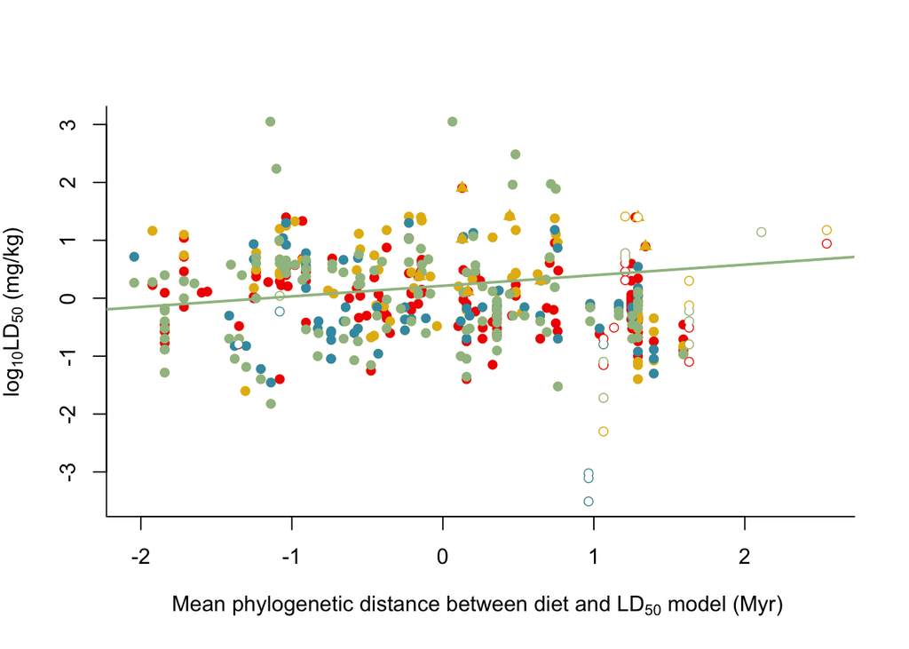

```r
###plots
###LD50

#pdf("ld50_plot.pdf")

plot(mydat.MAX$ld50 ~ (mydat.MAX$weigted.dist.v),
     pch = 16,
     xlab=  expression(paste("Mean phylogenetic distance between diet and ",
     LD[50],
     " model (Myr)",
     sep= " ")),
     ylab = expression(paste(log[10]*LD[50],
     " (mg/kg)")),
     bty = "l",
     col = pal[3])

points(mydat.MAX[mydat.MAX$ld50_method == "iv", "ld50"] ~
         mydat.MAX[mydat.MAX$ld50_method == "iv", "weigted.dist.v"],
       pch = 16,
       col = pal[4])

points(mydat.MAX[mydat.MAX$ld50_method == "sc", "ld50"] ~
         mydat.MAX[mydat.MAX$ld50_method == "sc" , "weigted.dist.v"],
       pch = 16,
       col = pal[3])

points(mydat.MAX[mydat.MAX$ld50_method == "im", "ld50"] ~
         mydat.MAX[mydat.MAX$ld50_method == "im" , "weigted.dist.v"],
       pch = 16,
       col = pal[1])

points(mydat.MAX[mydat.MAX$ld50_method == "ip", "ld50"] ~
         mydat.MAX[mydat.MAX$ld50_method == "ip" , "weigted.dist.v"],
       pch = 16,
       col = pal[2])

points(mydat.MAX[mydat.MAX$egg.bin == "yes", "ld50"] ~
         mydat.MAX[mydat.MAX$egg.bin == "yes" , "weigted.dist.v"],
       pch = 17,
       col = pal[3])


points(mydat.MAX[ mydat.MAX$species ==  "Thamnophis_elegans", "ld50"] ~
       mydat.MAX[ mydat.MAX$species ==  "Thamnophis_elegans", "weigted.dist.v"]
       , col = "white",
       pch = 20)

points(mydat.MAX[ mydat.MAX$species ==  "Emydocephalus_annulatus", "ld50"] ~
       mydat.MAX[ mydat.MAX$species ==  "Emydocephalus_annulatus", "weigted.dist.v"]
       , col = "white",
       pch = 20)

points(mydat.MAX[ mydat.MAX$species ==  "Causus_rhombeatus", "ld50"] ~
       mydat.MAX[ mydat.MAX$species ==  "Causus_rhombeatus", "weigted.dist.v"]
       , col = "white",
       pch = 20)


points(mydat.MAX[ mydat.MAX$species ==  "Agkistrodon_piscivorus", "ld50"] ~
       mydat.MAX[ mydat.MAX$species ==  "Agkistrodon_piscivorus", "weigted.dist.v"]
       , col = "white",
       pch = 20)

points(mydat.MAX[ mydat.MAX$species ==  "Ophiophagus_hannah", "ld50"] ~
       mydat.MAX[ mydat.MAX$species ==  "Ophiophagus_hannah", "weigted.dist.v"]
       , col = "white",
       pch = 20)

points(mydat.MAX[ mydat.MAX$species ==  "Daboia_russelii", "ld50"] ~
       mydat.MAX[ mydat.MAX$species ==  "Daboia_russelii", "weigted.dist.v"]
       , col = "white",
       pch = 20)

points(mydat.MAX[ mydat.MAX$species ==  "Bungarus_multicinctus", "ld50"] ~
       mydat.MAX[ mydat.MAX$species ==  "Bungarus_multicinctus", "weigted.dist.v"]
       , col = "white",
       pch = 20)

points(mydat.MAX[ mydat.MAX$species ==  "Oxyuranus_scutellatus", "ld50"] ~
       mydat.MAX[ mydat.MAX$species ==  "Oxyuranus_scutellatus", "weigted.dist.v"]
       , col = "white",
       pch = 20)


abline(summary(full_model)$solutions[1,1],
       summary(full_model)$solutions[15,1],
       col = pal[2],
       lw =2)
```

```r
#dev.off()
```

# plot phylo

We can also plot the phylogeny

```r
#First make a named vector of the mean trait value.

plot_LD50 <- vector()
plot_vol <- vector()


for(i in 1:length(levels(species))){

  plot_LD50[i] <-  min(ld50_data[ ld50_data$species ==  levels(species)[i] ,
                                  "ld50_mg"])
  plot_vol[i] <-  (ld50_data[ ld50_data$species ==  levels(species)[i] ,
                              "venom_yield_mg"])

}
```

[output not shown]

[output cut: 160 more lines]

[output not shown]

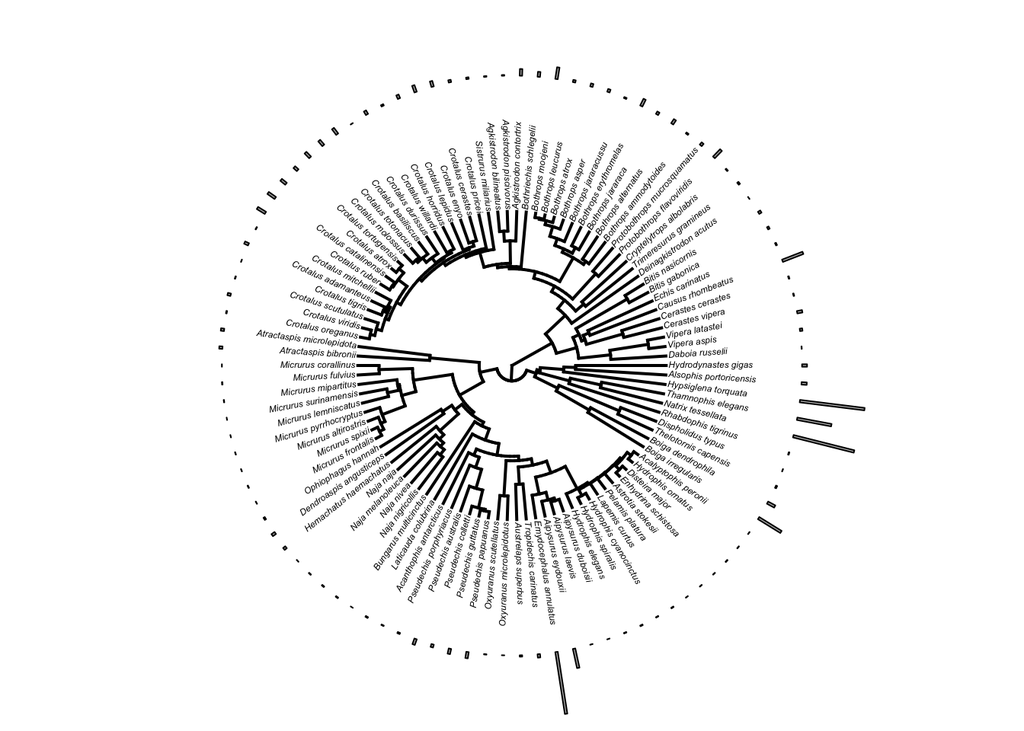

```r
names(plot_LD50) <- sort(max.tree$tip.label)
names(plot_vol) <- sort(max.tree$tip.label)

#pdf("phylobar_ld50.pdf")
plotTree.wBars(tree = max.tree,
               x = plot_LD50,
               scale= 1,
               type="fan",
               cex = 0.2,
               tip.labels = T,
               fsize=0.37,
               width = 1)
```

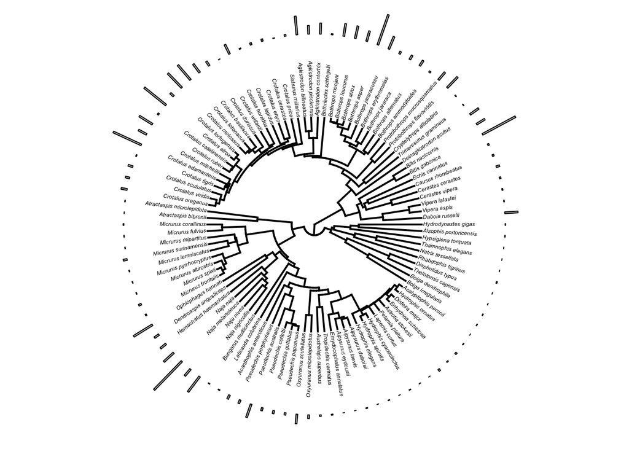

```r
#dev.off()

#pdf("phylobar_vol.pdf")
plotTree.wBars(tree = max.tree,
               x = plot_vol,
               scale= 0.04,
               type="fan",
               cex = 0.2,
               tip.labels = T,
               fsize=0.37,
               width = 1)
```

```r
#dev.off()
```

# Supplemntary models

Now lets rerun the analysis for when we include constriction, family level and prey size.

## Run the constriction model

Constriction Model

```r
#if you want to include species and ld50 method as a fixed term.
prior<-list(R = list(V = diag(2), nu=0.002),
            G = list(G1=list(V = diag(2)/2,n = 2,
                             alpha.mu=rep(0,2),
                             alpha.V=diag(2)*10^3),
                     G2=list(V = diag(2)/2,n = 2,
                             alpha.mu=rep(0,2),
                             alpha.V=diag(2)*10^3)))


######for constriction
con_mod <- MCMCglmm(cbind(vol.v,ld50) ~
                      trait:mass.aa +
                      trait:ld50_method+
                      trait:con +
                      trait:dim +
                      trait:egg.bin +
                      trait:weigted.dist.v,
                    random = ~us(trait):animal +
                              us(trait):species,
                    rcov=~us(trait):units,
                    data = mydat.MAX,
                    pedigree = max.tree,
                    prior = prior,
                    family=c("gaussian","gaussian"),
                    nitt = nitt, thin = thin, burnin = burnin,
                    verbose = FALSE)


summary(con_mod)
```

```
##
##  Iterations = 2001:11996
##  Thinning interval  = 5
##  Sample size  = 2000
##
##  DIC: -60.1932
##
##  G-structure:  ~us(trait):animal
##
##                              post.mean   l-95% CI u-95% CI eff.samp
## traitvol.v:traitvol.v.animal   0.28304  2.650e-07   0.6267    14.49
## traitld50:traitvol.v.animal   -0.01548 -2.086e-01   0.1872   169.02
## traitvol.v:traitld50.animal   -0.01548 -2.086e-01   0.1872   169.02
## traitld50:traitld50.animal     0.42964  1.538e-01   0.6956   248.54
##
##                ~us(trait):species
##
##                               post.mean   l-95% CI u-95% CI eff.samp
## traitvol.v:traitvol.v.species   0.31212  1.540e-01  0.47942    33.95
## traitld50:traitvol.v.species    0.02210 -3.565e-02  0.08873   355.82
## traitvol.v:traitld50.species    0.02210 -3.565e-02  0.08873   355.82
## traitld50:traitld50.species     0.03272  2.614e-09  0.09303   265.88
##
##  R-structure:  ~us(trait):units
##
##                             post.mean  l-95% CI u-95% CI eff.samp
## traitvol.v:traitvol.v.units 0.0087985  0.007649 0.010285     2214
## traitld50:traitvol.v.units  0.0007921 -0.003998 0.005518     2000
## traitvol.v:traitld50.units  0.0007921 -0.003998 0.005518     2000
## traitld50:traitld50.units   0.2279449  0.193780 0.262888     2000
##
##  Location effects: cbind(vol.v, ld50) ~ trait:mass.aa + trait:ld50_method + trait:con + trait:dim + trait:egg.bin + trait:weigted.dist.v
##
##                           post.mean  l-95% CI  u-95% CI eff.samp  pMCMC
## (Intercept)                0.226298 -0.091966  0.587698   929.23  0.170
## traitvol.v:mass.aa         0.484454  0.428411  0.541778   933.49 <5e-04
## traitld50:mass.aa          0.084245 -0.007719  0.174268  1776.35  0.070
## traitvol.v:ld50_methodiv  -0.001320 -0.033727  0.027390  2000.00  0.946
## traitld50:ld50_methodiv   -0.449317 -0.600943 -0.294495  2000.00 <5e-04
## traitvol.v:ld50_methodip  -0.013316 -0.049623  0.017146  2000.00  0.411
```

[output cut: 16 more lines]

```
## traitld50:ld50_methodiv   ***
## traitvol.v:ld50_methodip
## traitld50:ld50_methodip   ***
## traitvol.v:ld50_methodim
## traitld50:ld50_methodim   .
## traitvol.v:conyes
## traitld50:conyes
## traitvol.v:dim3           ***
## traitld50:dim3
## traitvol.v:egg.binyes     .
## traitld50:egg.binyes      ***
## traitvol.v:weigted.dist.v
## traitld50:weigted.dist.v  ***
## ---
## Signif. codes:  0 '***' 0.001 '**' 0.01 '*' 0.05 '.' 0.1 ' ' 1
```

```r
ld_50_con_phlyo <- con_mod$VCV[,"traitld50:traitld50.animal"]/
                    (con_mod$VCV[,"traitld50:traitld50.animal"] +
                     con_mod$VCV[,"traitld50:traitld50.species"] +
                     con_mod$VCV[,"traitld50:traitld50.units"] +
                         con_mod$VCV[,"traitld50:traitvol.v.animal"] +
                         con_mod$VCV[,"traitld50:traitvol.v.species"] +
                         con_mod$VCV[,"traitld50:traitvol.v.units"])

ld_50_con_species <- con_mod$VCV[,"traitld50:traitld50.species"]/
                    (con_mod$VCV[,"traitld50:traitld50.animal"] +
                     con_mod$VCV[,"traitld50:traitld50.species"] +
                     con_mod$VCV[,"traitld50:traitld50.units"]+
                         con_mod$VCV[,"traitld50:traitvol.v.animal"] +
                         con_mod$VCV[,"traitld50:traitvol.v.species"] +
                         con_mod$VCV[,"traitld50:traitvol.v.units"])

ld_50_con_units <- con_mod$VCV[,"traitld50:traitld50.units"]/
                    (con_mod$VCV[,"traitld50:traitld50.animal"] +
                     con_mod$VCV[,"traitld50:traitld50.species"] +
                     con_mod$VCV[,"traitld50:traitld50.units"]+
                         con_mod$VCV[,"traitld50:traitvol.v.animal"] +
                         con_mod$VCV[,"traitld50:traitvol.v.species"] +
                         con_mod$VCV[,"traitld50:traitvol.v.units"])

hdr(ld_50_con_phlyo)
```

```
## $hdr
##          [,1]      [,2]
## 99% 0.2265601 0.9834027
## 95% 0.3285870 0.8719140
## 50% 0.5371701 0.6983039
##
## $mode
## [1] 0.6216095
##
## $falpha
##         1%         5%        50%
## 0.09074394 0.40327518 2.41530620
```

```r
hdr(ld_50_con_species)
```

```
## $hdr
##             [,1]       [,2]      [,3]      [,4]      [,5]      [,6]
## 99% -0.006331134 0.19605524 0.2015669 0.2082508 0.2170784 0.2389047
## 95% -0.005329024 0.15782013 0.1876478 0.1880629        NA        NA
## 50% -0.002828907 0.03542116        NA        NA        NA        NA
##
## $mode
## [1] 0.001786622
##
## $falpha
##        1%        5%       50%
## 0.3200319 0.9610927 7.4298266
```

```r
hdr(ld_50_con_units)
```

```
## $hdr
##          [,1]      [,2]
## 99% 0.1512933 0.5833085
## 95% 0.1889997 0.5038702
## 50% 0.2770272 0.3769456
##
## $mode
## [1] 0.3261289
##
## $falpha
##        1%        5%       50%
## 0.1920641 0.7967441 4.0190966
```

```r
vol_con_phlyo <-  con_mod$VCV[,"traitvol.v:traitvol.v.animal"]/
                    (con_mod$VCV[,"traitvol.v:traitvol.v.animal"] +
                     con_mod$VCV[,"traitvol.v:traitvol.v.species"] +
                     con_mod$VCV[,"traitvol.v:traitvol.v.units"] +
                         con_mod$VCV[,"traitld50:traitvol.v.animal"] +
                         con_mod$VCV[,"traitld50:traitvol.v.species"] +
                         con_mod$VCV[,"traitld50:traitvol.v.units"])

vol_con_spec <-  con_mod$VCV[,"traitld50:traitvol.v.species"]/
                    (con_mod$VCV[,"traitvol.v:traitvol.v.animal"] +
                     con_mod$VCV[,"traitvol.v:traitvol.v.species"] +
                     con_mod$VCV[,"traitvol.v:traitvol.v.units"] +
                         con_mod$VCV[,"traitld50:traitvol.v.animal"] +
                         con_mod$VCV[,"traitld50:traitvol.v.species"] +
                         con_mod$VCV[,"traitld50:traitvol.v.units"])

vol_con_units <-  con_mod$VCV[,"traitvol.v:traitvol.v.units"]/
                    (con_mod$VCV[,"traitvol.v:traitvol.v.animal"] +
                     con_mod$VCV[,"traitvol.v:traitvol.v.species"] +
                     con_mod$VCV[,"traitvol.v:traitvol.v.units"] +
                         con_mod$VCV[,"traitld50:traitvol.v.animal"] +
                         con_mod$VCV[,"traitld50:traitvol.v.species"] +
                         con_mod$VCV[,"traitld50:traitvol.v.units"])


hdr(vol_con_phlyo)
```

```
## $hdr
##            [,1]      [,2]      [,3]      [,4]
## 99% -0.07787154 1.0079618        NA        NA
## 95% -0.03065486 0.8403782        NA        NA
## 50%  0.04898919 0.0872103 0.3726653 0.6732709
##
## $mode
## [1] 0.4940363
##
## $falpha
##        1%        5%       50%
## 0.1181694 0.4743878 1.1991074
```

```r
hdr(vol_con_spec)
```

```
## $hdr
##            [,1]       [,2]
## 99% -0.10457843 0.19882986
## 95% -0.06396207 0.14998268
## 50% -0.01072143 0.04952428
##
## $mode
## [1] 0.006241417
##
## $falpha
##        1%        5%       50%
## 0.2233252 0.7540884 6.3924110
```

```r
hdr(vol_con_units)
```

```
## $hdr
##            [,1]       [,2]
## 99% 0.006288562 0.02699839
## 95% 0.007973457 0.02315021
## 50% 0.011780164 0.01701178
##
## $mode
## [1] 0.01424484
##
## $falpha
##        1%        5%       50%
##  3.702782 16.562387 80.899417
```

## Run the environment model

Model with environment type included

```r
#if you want to include species and ld50 method as a fixed term.
prior<-list(R = list(V = diag(2), nu=0.002),
            G = list(G1=list(V = diag(2)/2,n = 2,
                             alpha.mu=rep(0,2),
                             alpha.V=diag(2)*10^3),
                     G2=list(V = diag(2)/2,n = 2,
                             alpha.mu=rep(0,2),
                             alpha.V=diag(2)*10^3)))

######for environment
env_mod <- MCMCglmm(cbind(vol.v,ld50) ~
                      trait:mass.aa +
                      trait:ld50_method +
                      trait:env +
                      trait:egg.bin +
                      trait:weigted.dist.v,
                    random = ~us(trait):animal +
                              us(trait):species,
                    rcov=~us(trait):units,
                    data = mydat.MAX,
                    pedigree = max.tree,
                    prior = prior,
                    family=c("gaussian","gaussian"),
                    nitt = nitt, thin =thin, burnin = burnin,
                    verbose = FALSE)

summary(env_mod)
```

```
##
##  Iterations = 2001:11996
##  Thinning interval  = 5
##  Sample size  = 2000
##
##  DIC: -53.92001
##
##  G-structure:  ~us(trait):animal
##
##                              post.mean l-95% CI u-95% CI eff.samp
## traitvol.v:traitvol.v.animal 0.5774341   0.2288   0.9574    355.1
## traitld50:traitvol.v.animal  0.0003473  -0.2035   0.2396    345.8
## traitvol.v:traitld50.animal  0.0003473  -0.2035   0.2396    345.8
## traitld50:traitld50.animal   0.3883779   0.1055   0.6385    296.5
##
##                ~us(trait):species
##
##                               post.mean   l-95% CI u-95% CI eff.samp
## traitvol.v:traitvol.v.species   0.22988  1.128e-01   0.3420    193.5
## traitld50:traitvol.v.species    0.02574 -3.725e-02   0.0935    297.5
## traitvol.v:traitld50.species    0.02574 -3.725e-02   0.0935    297.5
## traitld50:traitld50.species     0.03941  2.698e-08   0.1082    275.0
##
##  R-structure:  ~us(trait):units
##
##                             post.mean  l-95% CI u-95% CI eff.samp
## traitvol.v:traitvol.v.units 0.0088541  0.007558 0.010287     2690
## traitld50:traitvol.v.units  0.0009018 -0.003411 0.006039     2000
## traitvol.v:traitld50.units  0.0009018 -0.003411 0.006039     2000
## traitld50:traitld50.units   0.2302870  0.197118 0.265026     2000
##
##  Location effects: cbind(vol.v, ld50) ~ trait:mass.aa + trait:ld50_method + trait:env + trait:egg.bin + trait:weigted.dist.v
##
##                           post.mean  l-95% CI  u-95% CI eff.samp  pMCMC
## (Intercept)                0.198335 -0.205725  0.594520     1564  0.311
## traitvol.v:mass.aa         0.475955  0.422495  0.532872     1660 <5e-04
## traitld50:mass.aa          0.084853 -0.006219  0.184518     1736  0.084
## traitvol.v:ld50_methodiv  -0.001018 -0.031984  0.030476     2000  0.935
## traitld50:ld50_methodiv   -0.453124 -0.603032 -0.297045     2000 <5e-04
## traitvol.v:ld50_methodip  -0.014374 -0.048162  0.017139     2650  0.413
```

[output cut: 16 more lines]

```
## traitld50:ld50_methodiv   ***
## traitvol.v:ld50_methodip
## traitld50:ld50_methodip   ***
## traitvol.v:ld50_methodim
## traitld50:ld50_methodim   .
## traitvol.v:envarboreal    *
## traitld50:envarboreal
## traitvol.v:envaquatic
## traitld50:envaquatic      .
## traitvol.v:egg.binyes     *
## traitld50:egg.binyes      ***
## traitvol.v:weigted.dist.v
## traitld50:weigted.dist.v  ***
## ---
## Signif. codes:  0 '***' 0.001 '**' 0.01 '*' 0.05 '.' 0.1 ' ' 1
```

```r
ld_50_env_phlyo <- env_mod$VCV[,"traitld50:traitld50.animal"]/
                    (env_mod$VCV[,"traitld50:traitld50.animal"] +
                     env_mod$VCV[,"traitld50:traitld50.species"] +
                     env_mod$VCV[,"traitld50:traitld50.units"] +
                         env_mod$VCV[,"traitld50:traitvol.v.animal"] +
                         env_mod$VCV[,"traitld50:traitvol.v.species"] +
                         env_mod$VCV[,"traitld50:traitvol.v.units"])

ld_50_env_species <- env_mod$VCV[,"traitld50:traitld50.species"]/
                    (env_mod$VCV[,"traitld50:traitld50.animal"] +
                     env_mod$VCV[,"traitld50:traitld50.species"] +
                     env_mod$VCV[,"traitld50:traitld50.units"]+
                         env_mod$VCV[,"traitld50:traitvol.v.animal"] +
                         env_mod$VCV[,"traitld50:traitvol.v.species"] +
                         env_mod$VCV[,"traitld50:traitvol.v.units"])

ld_50_env_units <- env_mod$VCV[,"traitld50:traitld50.units"]/
                    (env_mod$VCV[,"traitld50:traitld50.animal"] +
                     env_mod$VCV[,"traitld50:traitld50.species"] +
                     env_mod$VCV[,"traitld50:traitld50.units"]+
                         env_mod$VCV[,"traitld50:traitvol.v.animal"] +
                         env_mod$VCV[,"traitld50:traitvol.v.species"] +
                         env_mod$VCV[,"traitld50:traitvol.v.units"])

hdr(ld_50_env_phlyo)
```

```
## $hdr
##          [,1]      [,2]
## 99% 0.1725465 0.9762372
## 95% 0.2578214 0.8359924
## 50% 0.4754132 0.6633767
##
## $mode
## [1] 0.5821848
##
## $falpha
##         1%         5%        50%
## 0.08832051 0.42950696 2.13382914
```

```r
hdr(ld_50_env_species)
```

```
## $hdr
##             [,1]       [,2]      [,3]      [,4]      [,5]      [,6]
## 99% -0.008985381 0.25326008 0.2830192 0.2890505        NA        NA
## 95% -0.007021860 0.17306717 0.1793918 0.1907385 0.1944474 0.2010932
## 50% -0.002864786 0.04557057        NA        NA        NA        NA
##
## $mode
## [1] 0.003123851
##
## $falpha
##        1%        5%       50%
## 0.2690953 1.0345746 7.2089694
```

```r
hdr(ld_50_env_units)
```

```
## $hdr
##          [,1]      [,2]
## 99% 0.1437375 0.6314754
## 95% 0.1915877 0.5218225
## 50% 0.2786149 0.3911692
##
## $mode
## [1] 0.3346571
##
## $falpha
##        1%        5%       50%
## 0.1476817 0.8366686 3.5898030
```

```r
vol_env_phlyo <-  env_mod$VCV[,"traitvol.v:traitvol.v.animal"]/
                    (env_mod$VCV[,"traitvol.v:traitvol.v.animal"] +
                     env_mod$VCV[,"traitvol.v:traitvol.v.species"] +
                     env_mod$VCV[,"traitvol.v:traitvol.v.units"] +
                         env_mod$VCV[,"traitld50:traitvol.v.animal"] +
                         env_mod$VCV[,"traitld50:traitvol.v.species"] +
                         env_mod$VCV[,"traitld50:traitvol.v.units"])

vol_env_spec <-  env_mod$VCV[,"traitld50:traitvol.v.species"]/
                    (env_mod$VCV[,"traitvol.v:traitvol.v.animal"] +
                     env_mod$VCV[,"traitvol.v:traitvol.v.species"] +
                     env_mod$VCV[,"traitvol.v:traitvol.v.units"] +
                         env_mod$VCV[,"traitld50:traitvol.v.animal"] +
                         env_mod$VCV[,"traitld50:traitvol.v.species"] +
                         env_mod$VCV[,"traitld50:traitvol.v.units"])

vol_env_units <-  env_mod$VCV[,"traitvol.v:traitvol.v.units"]/
                    (env_mod$VCV[,"traitvol.v:traitvol.v.animal"] +
                     env_mod$VCV[,"traitvol.v:traitvol.v.species"] +
                     env_mod$VCV[,"traitvol.v:traitvol.v.units"] +
                         env_mod$VCV[,"traitld50:traitvol.v.animal"] +
                         env_mod$VCV[,"traitld50:traitvol.v.species"] +
                         env_mod$VCV[,"traitld50:traitvol.v.units"])


hdr(vol_env_phlyo)
```

```
## $hdr
##          [,1]      [,2]
## 99% 0.2859224 1.0987335
## 95% 0.3972503 0.9560107
## 50% 0.5783729 0.7653018
##
## $mode
## [1] 0.6703894
##
## $falpha
##        1%        5%       50%
## 0.1058081 0.5041019 2.1292415
```

```r
hdr(vol_env_spec)
```

```
## $hdr
##             [,1]        [,2]       [,3]      [,4]      [,5]      [,6]
## 99% -0.078231865 -0.07721014 -0.0635633 0.1568514 0.1590204 0.1759028
## 95% -0.043807005  0.11950755         NA        NA        NA        NA
## 50% -0.005793416  0.04535137         NA        NA        NA        NA
##
## $mode
## [1] 0.003469576
##
## $falpha
##        1%        5%       50%
## 0.2952196 1.2009901 8.4393691
```

```r
hdr(vol_env_units)
```

```
## $hdr
##            [,1]       [,2]       [,3]       [,4]
## 99% 0.005575848 0.01888781 0.01949289 0.01962362
## 95% 0.005906830 0.01654230         NA         NA
## 50% 0.008269576 0.01027840 0.01028800 0.01179491
##
## $mode
## [1] 0.00972387
##
## $falpha
##         1%         5%        50%
##   7.953084  21.825535 125.613895
```

## family model

Model with family level included

```r
#if you want to include species and ld50 method as a fixed term.
prior<-list(R = list(V = diag(2), nu=0.002),
            G = list(G1=list(V = diag(2)/2,n = 2,
                             alpha.mu=rep(0,2),
                             alpha.V=diag(2)*10^3),
                     G2=list(V = diag(2)/2,n = 2,
                             alpha.mu=rep(0,2),
                             alpha.V=diag(2)*10^3)))


######for constriction
fam_mod <- MCMCglmm(cbind(vol.v,ld50) ~ trait:mass.aa +
                      trait:ld50_method +
                      trait:fam +
                      trait:dim +
                      trait:egg.bin +
                      trait:weigted.dist.v,
                    random = ~us(trait):animal +
                              us(trait):species,
                    rcov=~us(trait):units,
                    data = mydat.MAX,
                    pedigree = max.tree,
                    prior = prior,
                    family=c("gaussian","gaussian"),
                    nitt = nitt, thin =thin, burnin = burnin,
                    verbose = FALSE)


ld_50_fam_phlyo <- fam_mod$VCV[,"traitld50:traitld50.animal"]/
                    (fam_mod$VCV[,"traitld50:traitld50.animal"] +
                     fam_mod$VCV[,"traitld50:traitld50.species"] +
                     fam_mod$VCV[,"traitld50:traitld50.units"] +
                         fam_mod$VCV[,"traitld50:traitvol.v.animal"] +
                         fam_mod$VCV[,"traitld50:traitvol.v.species"] +
                         fam_mod$VCV[,"traitld50:traitvol.v.units"])

ld_50_fam_species <- fam_mod$VCV[,"traitld50:traitld50.species"]/
                    (fam_mod$VCV[,"traitld50:traitld50.animal"] +
                     fam_mod$VCV[,"traitld50:traitld50.species"] +
                     fam_mod$VCV[,"traitld50:traitld50.units"]+
                         fam_mod$VCV[,"traitld50:traitvol.v.animal"] +
                         fam_mod$VCV[,"traitld50:traitvol.v.species"] +
                         fam_mod$VCV[,"traitld50:traitvol.v.units"])

ld_50_fam_units <- fam_mod$VCV[,"traitld50:traitld50.units"]/
                    (fam_mod$VCV[,"traitld50:traitld50.animal"] +
                     fam_mod$VCV[,"traitld50:traitld50.species"] +
                     fam_mod$VCV[,"traitld50:traitld50.units"]+
                         fam_mod$VCV[,"traitld50:traitvol.v.animal"] +
                         fam_mod$VCV[,"traitld50:traitvol.v.species"] +
                         fam_mod$VCV[,"traitld50:traitvol.v.units"])

hdr(ld_50_fam_phlyo)
```

```
## $hdr
##             [,1]      [,2]      [,3]      [,4]
## 99% -0.069202338 0.9143140        NA        NA
## 95% -0.004566618 0.1321897 0.1596769 0.7978043
## 50%  0.447177823 0.7122159        NA        NA
##
## $mode
## [1] 0.5886147
##
## $falpha
##       1%       5%      50%
## 0.138641 0.593011 1.311104
```

```r
hdr(ld_50_fam_species)
```

```
## $hdr
##            [,1]       [,2]      [,3]       [,4]      [,5]      [,6]
## 99% -0.01416727 0.44004591        NA         NA        NA        NA
## 95% -0.01180696 0.21277010 0.2176492 0.32480610 0.3356758 0.3748078
## 50% -0.00639156 0.06199563 0.0634593 0.07557807        NA        NA
##
## $mode
## [1] 0.004685003
##
## $falpha
##        1%        5%       50%
## 0.3372553 0.8355964 3.9364422
```

```r
hdr(ld_50_fam_units)
```

```
## $hdr
##          [,1]      [,2]
## 99% 0.1557973 0.6704523
## 95% 0.1868200 0.5983186
## 50% 0.2713114 0.4227152
##
## $mode
## [1] 0.3353121
##
## $falpha
##        1%        5%       50%
## 0.2756856 0.7640147 2.8044154
```

```r
vol_fam_phlyo <-  fam_mod$VCV[,"traitvol.v:traitvol.v.animal"]/
                    (fam_mod$VCV[,"traitvol.v:traitvol.v.animal"] +
                     fam_mod$VCV[,"traitvol.v:traitvol.v.species"] +
                     fam_mod$VCV[,"traitvol.v:traitvol.v.units"] +
                         fam_mod$VCV[,"traitld50:traitvol.v.animal"] +
                         fam_mod$VCV[,"traitld50:traitvol.v.species"] +
                         fam_mod$VCV[,"traitld50:traitvol.v.units"])

vol_fam_spec <-  fam_mod$VCV[,"traitld50:traitvol.v.species"]/
                    (fam_mod$VCV[,"traitvol.v:traitvol.v.animal"] +
                     fam_mod$VCV[,"traitvol.v:traitvol.v.species"] +
                     fam_mod$VCV[,"traitvol.v:traitvol.v.units"] +
                         fam_mod$VCV[,"traitld50:traitvol.v.animal"] +
                         fam_mod$VCV[,"traitld50:traitvol.v.species"] +
                         fam_mod$VCV[,"traitld50:traitvol.v.units"])

vol_fam_units <-  fam_mod$VCV[,"traitvol.v:traitvol.v.units"]/
                    (fam_mod$VCV[,"traitvol.v:traitvol.v.animal"] +
                     fam_mod$VCV[,"traitvol.v:traitvol.v.species"] +
                     fam_mod$VCV[,"traitvol.v:traitvol.v.units"] +
                         fam_mod$VCV[,"traitld50:traitvol.v.animal"] +
                         fam_mod$VCV[,"traitld50:traitvol.v.species"] +
                         fam_mod$VCV[,"traitld50:traitvol.v.units"])


hdr(vol_fam_phlyo)
```

```
## $hdr
##             [,1]      [,2]
## 99% -0.001980411 0.9030008
## 95%  0.065274413 0.7984658
## 50%  0.317081316 0.5975121
##
## $mode
## [1] 0.47197
##
## $falpha
##        1%        5%       50%
## 0.1797696 0.4664941 1.4856242
```

```r
hdr(vol_fam_spec)
```

```
## $hdr
##            [,1]        [,2]        [,3]      [,4]
## 99% -0.11305658 -0.09636661 -0.09200668 0.2164663
## 95% -0.06733944  0.15958785          NA        NA
## 50% -0.01134035  0.05466384          NA        NA
##
## $mode
## [1] 0.003595292
##
## $falpha
##        1%        5%       50%
## 0.2262812 0.7542530 6.1707884
```

```r
hdr(vol_fam_units)
```

```
## $hdr
##            [,1]       [,2]       [,3]       [,4]
## 99% 0.006076167 0.02758565         NA         NA
## 95% 0.007328328 0.02332633         NA         NA
## 50% 0.010711580 0.01577219 0.01631466 0.01676427
##
## $mode
## [1] 0.01207812
##
## $falpha
##       1%       5%      50%
##  3.04398 15.27431 75.67575
```

```r
summary(fam_mod)
```

```
##
##  Iterations = 2001:11996
##  Thinning interval  = 5
##  Sample size  = 2000
##
##  DIC: -58.73635
##
##  G-structure:  ~us(trait):animal
##
##                              post.mean   l-95% CI u-95% CI eff.samp
## traitvol.v:traitvol.v.animal  0.301327  1.837e-02   0.6420    39.64
## traitld50:traitvol.v.animal   0.005298 -1.944e-01   0.2047   201.87
## traitvol.v:traitld50.animal   0.005298 -1.944e-01   0.2047   201.87
## traitld50:traitld50.animal    0.327802  3.310e-08   0.6569    70.12
##
##                ~us(trait):species
##
##                               post.mean   l-95% CI u-95% CI eff.samp
## traitvol.v:traitvol.v.species   0.30167  1.622e-01  0.44564    78.61
## traitld50:traitvol.v.species    0.02251 -3.550e-02  0.09489   351.43
## traitvol.v:traitld50.species    0.02251 -3.550e-02  0.09489   351.43
## traitld50:traitld50.species     0.06068  2.168e-08  0.16608    92.31
##
##  R-structure:  ~us(trait):units
##
##                             post.mean  l-95% CI u-95% CI eff.samp
## traitvol.v:traitvol.v.units 0.0087844  0.007516 0.010273     2000
## traitld50:traitvol.v.units  0.0007083 -0.004209 0.005688     2000
## traitvol.v:traitld50.units  0.0007083 -0.004209 0.005688     2000
## traitld50:traitld50.units   0.2293089  0.194832 0.263428     2000
##
##  Location effects: cbind(vol.v, ld50) ~ trait:mass.aa + trait:ld50_method + trait:fam + trait:dim + trait:egg.bin + trait:weigted.dist.v
##
##                             post.mean  l-95% CI  u-95% CI eff.samp  pMCMC
## (Intercept)                  0.246691 -0.586731  1.130547    292.9  0.552
## traitvol.v:mass.aa           0.477490  0.424407  0.535383   2000.0 <5e-04
## traitld50:mass.aa            0.087116 -0.008167  0.176144   1598.3  0.072
## traitvol.v:ld50_methodiv    -0.001089 -0.033499  0.028004   2000.0  0.952
## traitld50:ld50_methodiv     -0.464676 -0.615393 -0.327769   1728.8 <5e-04
## traitvol.v:ld50_methodip    -0.013520 -0.045904  0.018355   2000.0  0.419
```

[output cut: 32 more lines]

```
## traitld50:famElapidae
## traitvol.v:famLamprophiidae
## traitld50:famLamprophiidae
## traitvol.v:famNatricidae
## traitld50:famNatricidae
## traitvol.v:famViperidae
## traitld50:famViperidae
## traitvol.v:dim3             ***
## traitld50:dim3
## traitvol.v:egg.binyes
## traitld50:egg.binyes        ***
## traitvol.v:weigted.dist.v
## traitld50:weigted.dist.v    ***
## ---
## Signif. codes:  0 '***' 0.001 '**' 0.01 '*' 0.05 '.' 0.1 ' ' 1
```

# Models including prey size

Set up the dataset which includes prey and has a matching phylogeny

```r
###full model
mydat.prey <- na.omit(data.frame(animal,
                                 species,
                                 mass,
                                 weigted.dist.v = weigted.dist.v,
                                 vol.v,
                                 dimensions = dimensions,
                                 ld50 = ld50_10,
                                 ld50_method,
                                 dimensions,
                                 egg.bin,
                                 env,
                                 con,
                                 fam,
                                 prey_mass = ld50_clean$prey_size_g,
                                 mod_class,
                                 prey_max = ld50_clean$max_prey_g))


mydat.prey <- mydat.prey[mydat.prey$animal != "Causus_rhombeatus",]


spec_dropped <-as.data.frame(matrix(0, nrow = c(length(levels(mydat.prey[,"species"]))),
                                    ncol = c(2),
                                    dimnames = list(c(),c("species","dummy"))))

spec_dropped[,1] <- levels(mydat.prey$species)
spec_dropped[,2] <- rep(0,length = c(length(levels(mydat.prey[,"species"]))))
spec_dropped <- as.data.frame(spec_dropped)

prey.dat <- comparative.data(data= spec_dropped,
                             phy= Tree,
                             names.col="species",
                             vcv=FALSE)

prey.tree <- chronoMPL(prey.dat$phy)

prey.dropped <- prey.dat$dropped$unmatched.rows

mydat.P <- mydat.prey
if((length(prey.dropped) > c(0)) == TRUE){
for(i in 1:(length(prey.dropped))){
mydat.P <-mydat.P[mydat.P$species != prey.dropped[i],]
}
}

mydat.P <- as.data.frame(as.matrix(mydat.P))

prey_mean <- (log10(as.numeric(as.character(mydat.P$prey_mass))) - mean(log10(as.numeric(as.character(mydat.P$prey_mass)))))/
  sd(log10(as.numeric(as.character(mydat.P$prey_mass))))


mydat.P <- data.frame(animal = mydat.P$species,
species = mydat.P$species,
mass.aa = (as.numeric(as.character(mydat.P$mass))),
weigted.dist.v = (as.numeric(as.character(mydat.P$weigted.dist.v))),
vol.v = (as.numeric(as.character(mydat.P$vol.v))),
ld50 = (as.numeric(as.character(mydat.P$ld50))),
ld50_method  =  factor(mydat.P$ld50_method,
                       levels = c("sc","iv","ip","im")),
dim = mydat.P$dimensions,
egg.bin = mydat.P$egg.bin,
env = factor(mydat.P$env,
             levels = c("terrestrial","arboreal","aquatic")),
con = mydat.P$con,
fam = mydat.P$fam,
mod_class_p = mydat.P$mod_class,
prey_mean = prey_mean)
```

## Prey model

Run the main model with prey size included

```r
#if you want to include species and ld50 method as a fixed term.
prior<-list(R = list(V = diag(2), nu=0.002),
            G = list(G1=list(V = diag(2)/2,n = 2,
                             alpha.mu=rep(0,2),
                             alpha.V=diag(2)*10^3),
                     G2=list(V = diag(2)/2,n = 2,
                             alpha.mu=rep(0,2),
                             alpha.V=diag(2)*10^3)))


nitt_p <- 120000
thin_p <- 50
burnin_p <- 20000


######with prey included
prey_mod_long <- MCMCglmm(cbind(vol.v,ld50) ~
                            trait:mass.aa +
                            trait:ld50_method +
                            trait:prey_mean +
                            trait:dim +
                            trait:egg.bin +
                            trait:weigted.dist.v,
                          random = ~us(trait):animal +
                                    us(trait):species,
                          rcov=~us(trait):units,
                          data = mydat.P,
                          pedigree = prey.tree,
                          prior = prior,
                          family=c("gaussian","gaussian"),
                          nitt = nitt_p, thin = thin_p, burnin = burnin_p,
                          verbose = FALSE)



ld_50_prey_phlyo <- prey_mod_long$VCV[,"traitld50:traitld50.animal"]/
                    (prey_mod_long$VCV[,"traitld50:traitld50.animal"] +
                     prey_mod_long$VCV[,"traitld50:traitld50.species"] +
                     prey_mod_long$VCV[,"traitld50:traitld50.units"])

ld_50_prey_species <- prey_mod_long$VCV[,"traitld50:traitld50.species"]/
                    (prey_mod_long$VCV[,"traitld50:traitld50.animal"] +
                     prey_mod_long$VCV[,"traitld50:traitld50.species"] +
                     prey_mod_long$VCV[,"traitld50:traitld50.units"])

ld_50_prey_units <- prey_mod_long$VCV[,"traitld50:traitld50.units"]/
                    (prey_mod_long$VCV[,"traitld50:traitld50.animal"] +
                     prey_mod_long$VCV[,"traitld50:traitld50.species"] +
                     prey_mod_long$VCV[,"traitld50:traitld50.units"])

hdr(ld_50_prey_phlyo)
```

```
## $hdr
##          [,1]      [,2]
## 99% 0.2706087 0.8988868
## 95% 0.4406453 0.8608440
## 50% 0.6583852 0.7706581
##
## $mode
## [1] 0.7163347
##
## $falpha
##         1%         5%        50%
## 0.09821542 0.47957923 3.39699375
```

```r
hdr(ld_50_prey_species)
```

```
## $hdr
##             [,1]       [,2]       [,3]       [,4]       [,5]       [,6]
## 99% -0.005762604 0.27454938 0.27607696 0.28481311 0.28592769 0.29205902
## 95% -0.004854680 0.15048383 0.15138682 0.18277619 0.18678769 0.19714094
## 50% -0.002608850 0.02385994 0.02497872 0.02824068 0.03476998 0.03505767
##          [,7]      [,8]      [,9]     [,10]     [,11]     [,12]     [,13]
## 99% 0.3039458 0.3079250 0.3245607 0.3298825 0.3468142 0.3486651 0.3616651
## 95% 0.2086196 0.2129998 0.2392308 0.2401217 0.2581377 0.2604480        NA
## 50%        NA        NA        NA        NA        NA        NA        NA
##         [,14]     [,15]     [,16]     [,17]     [,18]
## 99% 0.3624839 0.3751871 0.3774354 0.4898169 0.4914383
## 95%        NA        NA        NA        NA        NA
## 50%        NA        NA        NA        NA        NA
##
## $mode
## [1] 0.001787847
##
## $falpha
##        1%        5%       50%
## 0.1798271 0.7068256 7.6182463
```

```r
hdr(ld_50_prey_units)
```

```
## $hdr
##          [,1]      [,2]
## 99% 0.1276049 0.4389625
## 95% 0.1573651 0.3930841
## 50% 0.2256158 0.3047598
##
## $mode
## [1] 0.2643389
##
## $falpha
##        1%        5%       50%
## 0.4777068 1.3582831 4.9013732
```

```r
vol_prey_phlyo <-  prey_mod_long$VCV[,"traitvol.v:traitvol.v.animal"]/
                    (prey_mod_long$VCV[,"traitvol.v:traitvol.v.animal"] +
                     prey_mod_long$VCV[,"traitvol.v:traitvol.v.species"] +
                     prey_mod_long$VCV[,"traitvol.v:traitvol.v.units"])

vol_prey_spec <-  prey_mod_long$VCV[,"traitld50:traitvol.v.species"]/
                    (prey_mod_long$VCV[,"traitvol.v:traitvol.v.animal"] +
                     prey_mod_long$VCV[,"traitvol.v:traitvol.v.species"] +
                     prey_mod_long$VCV[,"traitvol.v:traitvol.v.units"])

vol_prey_units <-  prey_mod_long$VCV[,"traitvol.v:traitvol.v.units"]/
                    (prey_mod_long$VCV[,"traitvol.v:traitvol.v.animal"] +
                     prey_mod_long$VCV[,"traitvol.v:traitvol.v.species"] +
                     prey_mod_long$VCV[,"traitvol.v:traitvol.v.units"])


hdr(vol_prey_phlyo)
```

```
## $hdr
##           [,1]       [,2]      [,3]      [,4]      [,5]      [,6]
## 99% 0.01878684 0.02695424 0.1367200 0.1463901 0.1798193 0.2580358
## 95% 0.36601349 0.39379486 0.4311643 1.0108642        NA        NA
## 50% 0.87353778 0.99895077        NA        NA        NA        NA
##          [,7]     [,8]
## 99% 0.2768287 1.016169
## 95%        NA       NA
## 50%        NA       NA
##
## $mode
## [1] 0.9778621
##
## $falpha
##        1%        5%       50%
## 0.1008548 0.3289193 2.1716152
```

```r
hdr(vol_prey_spec)
```

```
## $hdr
##             [,1]        [,2]        [,3]        [,4]        [,5]
## 99% -0.193433580 -0.19136800 -0.18379182 -0.18194004 -0.14757299
## 95% -0.097574290 -0.09549363 -0.08542793 -0.08470773 -0.08304913
## 50% -0.009939973  0.01518070          NA          NA          NA
##            [,6]        [,7]        [,8]        [,9]       [,10]
## 99% -0.14569083 -0.14105019 -0.13394569 -0.13164156 -0.12999794
## 95% -0.07312865 -0.07094464  0.08417853  0.08876787  0.08940539
## 50%          NA          NA          NA          NA          NA
##           [,11]       [,12]       [,13]       [,14]      [,15]      [,16]
## 99% -0.12548895 -0.11861742 -0.11648903 -0.11300317 -0.1086253 -0.1040726
## 95%  0.09168678  0.09701025  0.09824264  0.09894421  0.1061973  0.1071052
## 50%          NA          NA          NA          NA         NA         NA
##          [,17]     [,18]     [,19]     [,20]     [,21]    [,22]    [,23]
## 99% -0.1019715 0.1020159 0.1046337 0.1103005 0.1135708 0.126437 0.127813
## 95%  0.1175413 0.1187817 0.1197621 0.1242996        NA       NA       NA
## 50%         NA        NA        NA        NA        NA       NA       NA
##         [,24]     [,25]     [,26]     [,27]     [,28]     [,29]     [,30]
## 99% 0.1298537 0.1392022 0.1477673 0.1508706 0.1558998 0.1563219 0.1587275
## 95%        NA        NA        NA        NA        NA        NA        NA
## 50%        NA        NA        NA        NA        NA        NA        NA
##         [,31]     [,32]
## 99% 0.2140392 0.2164203
## 95%        NA        NA
## 50%        NA        NA
##
## $mode
## [1] 9.063285e-05
##
## $falpha
##         1%         5%        50%
##  0.2439077  0.7099277 11.1351914
```

```r
hdr(vol_prey_units)
```

```
## $hdr
##            [,1]       [,2]
## 99% 0.006755672 0.03771846
## 95% 0.007452908 0.03150612
## 50% 0.011061246 0.01821378
##
## $mode
## [1] 0.0150623
##
## $falpha
##        1%        5%       50%
##  3.334720  7.635394 54.823101
```

```r
summary(prey_mod_long)
```

```
##
##  Iterations = 20001:119951
##  Thinning interval  = 50
##  Sample size  = 2000
##
##  DIC: 40.99885
##
##  G-structure:  ~us(trait):animal
##
##                              post.mean l-95% CI u-95% CI eff.samp
## traitvol.v:traitvol.v.animal   0.68837  0.07192   1.2608    114.8
## traitld50:traitvol.v.animal    0.01869 -0.22109   0.2728   2990.0
## traitvol.v:traitld50.animal    0.01869 -0.22109   0.2728   2990.0
## traitld50:traitld50.animal     0.52642  0.18023   0.8752   1172.1
##
##                ~us(trait):species
##
##                               post.mean   l-95% CI u-95% CI eff.samp
## traitvol.v:traitvol.v.species   0.10757  4.437e-07  0.28064      103
## traitld50:traitvol.v.species    0.00387 -5.237e-02  0.06818     1665
## traitvol.v:traitld50.species    0.00387 -5.237e-02  0.06818     1665
## traitld50:traitld50.species     0.03775  3.403e-10  0.13329     1454
##
##  R-structure:  ~us(trait):units
##
##                             post.mean  l-95% CI u-95% CI eff.samp
## traitvol.v:traitvol.v.units  0.013034  0.010657 0.015447     2000
## traitld50:traitvol.v.units   0.000883 -0.006264 0.007615     2303
## traitvol.v:traitld50.units   0.000883 -0.006264 0.007615     2303
## traitld50:traitld50.units    0.202056  0.167553 0.239224     2000
##
##  Location effects: cbind(vol.v, ld50) ~ trait:mass.aa + trait:ld50_method + trait:prey_mean + trait:dim + trait:egg.bin + trait:weigted.dist.v
##
##                           post.mean  l-95% CI  u-95% CI eff.samp  pMCMC
## (Intercept)                0.308539 -0.185711  0.744532     2000  0.170
## traitvol.v:mass.aa         0.482939  0.415340  0.552254     1879 <5e-04
## traitld50:mass.aa          0.075136 -0.059135  0.204625     2133  0.250
## traitvol.v:ld50_methodiv  -0.007110 -0.059449  0.043572     1849  0.815
## traitld50:ld50_methodiv   -0.396619 -0.578109 -0.203625     2000 <5e-04
## traitvol.v:ld50_methodip  -0.023098 -0.075559  0.030614     2000  0.400
```

[output cut: 16 more lines]

```
## traitld50:ld50_methodiv   ***
## traitvol.v:ld50_methodip
## traitld50:ld50_methodip   ***
## traitvol.v:ld50_methodim
## traitld50:ld50_methodim
## traitvol.v:prey_mean      **
## traitld50:prey_mean
## traitvol.v:dim3           **
## traitld50:dim3
## traitvol.v:egg.binyes
## traitld50:egg.binyes      **
## traitvol.v:weigted.dist.v
## traitld50:weigted.dist.v  ***
## ---
## Signif. codes:  0 '***' 0.001 '**' 0.01 '*' 0.05 '.' 0.1 ' ' 1
```

## Predator-prey size allometry

Model of predator prey allometry.

```r
#if you want to include species and ld50 method as a fixed term.
prior2<-list(R = list(V = 1, nu=0.002),
             G = list(G1=list(V = 1,n = 2,
                              alpha.mu= 0,
                              alpha.V = 10^3)))


######with prey included
prey_mass_mod <- MCMCglmm(prey_mean ~
                            mass.aa,
                          random = ~ animal,
                          rcov=~units,
                          data = mydat.P,
                          pedigree = prey.tree,
                          prior = prior2,
                          family=c("gaussian"),
                          nitt = 600000, thin =250, burnin = 100000,
                          verbose = FALSE)

summary(prey_mass_mod)
```

```
##
##  Iterations = 100001:599751
##  Thinning interval  = 250
##  Sample size  = 2000
##
##  DIC: -2728.784
##
##  G-structure:  ~animal
##
##        post.mean l-95% CI u-95% CI eff.samp
## animal     5.214    3.569    7.179     2000
##
##  R-structure:  ~units
##
##       post.mean  l-95% CI  u-95% CI eff.samp
## units 8.933e-06 7.251e-06 1.049e-05     2000
##
##  Location effects: prey_mean ~ mass.aa
##
##              post.mean   l-95% CI   u-95% CI eff.samp pMCMC
## (Intercept) -3.147e-01 -2.061e+00  1.397e+00     2000 0.727
## mass.aa     -1.646e-06 -1.958e-03  2.073e-03     2000 0.990
```